# 03-Regression

Tim Schoof

1/29/2021

# 3.6 Lab: Linear Regression

## Simple linear regression

```r
# code from the book
lm_fit <- lm(medv~lstat, data = boston)
summary(lm_fit)
```

```
##
## Call:
## lm(formula = medv ~ lstat, data = boston)
##
## Residuals:
##     Min      1Q  Median      3Q     Max
## -15.168  -3.990  -1.318   2.034  24.500
##
## Coefficients:
##             Estimate Std. Error t value Pr(>|t|)
## (Intercept) 34.55384    0.56263   61.41   <2e-16 ***
## lstat       -0.95005    0.03873  -24.53   <2e-16 ***
## ---
## Signif. codes:  0 '***' 0.001 '**' 0.01 '*' 0.05 '.' 0.1 ' ' 1
##
## Residual standard error: 6.216 on 504 degrees of freedom
## Multiple R-squared:  0.5441, Adjusted R-squared:  0.5432
## F-statistic: 601.6 on 1 and 504 DF,  p-value: < 2.2e-16
```

```r
# tidymodels way
# https://www.tidymodels.org/start/models/
tidy_lm_fit <-
  linear_reg() %>%
  set_engine("lm") %>%
  fit(medv~lstat, data = boston)

tidy(tidy_lm_fit)
```

```
## # A tibble: 2 x 5
##   term        estimate std.error statistic   p.value
##   <chr>          <dbl>     <dbl>     <dbl>     <dbl>
## 1 (Intercept)   34.6      0.563       61.4 3.74e-236
## 2 lstat         -0.950    0.0387     -24.5 5.08e- 88
```

We don’t get any of the model fit data here.

We can get that using `glance`. I’m not quite sure what that is/does.

```r
# https://www.tidymodels.org/learn/statistics/tidy-analysis/
tidy_lm_fit %>%
  glance()
```

```
## # A tibble: 1 x 11
##   r.squared adj.r.squared sigma statistic  p.value    df logLik   AIC   BIC
##       <dbl>         <dbl> <dbl>     <dbl>    <dbl> <int>  <dbl> <dbl> <dbl>
## 1     0.544         0.543  6.22      602. 5.08e-88     2 -1641. 3289. 3302.
## # ... with 2 more variables: deviance <dbl>, df.residual <int>
```

We can use the `names()` function to see what is stored in our linear regression fit objects. The objects, not surprisingly perhaps, store different things.

```r
names(lm_fit)
```

```
##  [1] "coefficients"  "residuals"     "effects"       "rank"
##  [5] "fitted.values" "assign"        "qr"            "df.residual"
##  [9] "xlevels"       "call"          "terms"         "model"
```

```r
names(tidy_lm_fit)
```

```
## [1] "lvl"     "spec"    "fit"     "preproc" "elapsed"
```

We use the `coef()` function to extract the coefficients.

```r
coef(lm_fit)
```

```
## (Intercept)       lstat
##  34.5538409  -0.9500494
```

Using the tidymodels approach, you actually already have the coefficients in a tidy format once you’ve run `tidy(tidy_lm_fit)` and you can just extract them like you would with any data frame or tibble.

```r
tidy_lm_fit %>%
  tidy() %>%
  select(term, estimate)
```

```
## # A tibble: 2 x 2
##   term        estimate
##   <chr>          <dbl>
## 1 (Intercept)   34.6
## 2 lstat         -0.950
```

Alternatively, we could get the coefficients directly from the stored object, although this feels a bit messy.

```r
tidy_lm_fit$fit$coefficients
```

```
## (Intercept)       lstat
##  34.5538409  -0.9500494
```

This https://stackoverflow.com/questions/63087592/how-to-extract-glmnet-coefficients-produced-by-tidymodels might be relevant for more advanced situations.

In order to obtain a confidence interval for the coefficient estimates, we can use the `confint()` command.

```r
confint(lm_fit)
```

```
##                 2.5 %     97.5 %
## (Intercept) 33.448457 35.6592247
## lstat       -1.026148 -0.8739505
```

I’m not sure how to get confidence intervals using tidymodels.

The predict() function can be used to produce confidence intervals and prediction intervals for the prediction of medv for a given value of lstat.

```r
predict(lm_fit, data.frame(lstat=c(5,10,15)), interval="confidence")
```

```
##        fit      lwr      upr
## 1 29.80359 29.00741 30.59978
## 2 25.05335 24.47413 25.63256
## 3 20.30310 19.73159 20.87461
```

Using the tidymodels packages we also use the `predict` function, but a bit differently apparently. To get the same output as above, I’m currently running two lines of code. Figuring out what the best way is to combine the two.

```r
predict(tidy_lm_fit, data.frame(lstat=c(5,10,15)))
```

```
## # A tibble: 3 x 1
##   .pred
##   <dbl>
## 1  29.8
## 2  25.1
## 3  20.3
```

```r
predict(tidy_lm_fit, data.frame(lstat=c(5,10,15)),type = "conf_int",
  level = 0.95)
```

```
## # A tibble: 3 x 2
##   .pred_lower .pred_upper
##         <dbl>       <dbl>
## 1        29.0        30.6
## 2        24.5        25.6
## 3        19.7        20.9
```

You can also get the prediction interval.

```r
predict(lm_fit, data.frame(lstat=c(5,10,15)), interval="prediction")
```

```
##        fit       lwr      upr
## 1 29.80359 17.565675 42.04151
## 2 25.05335 12.827626 37.27907
## 3 20.30310  8.077742 32.52846
```

```r
predict(tidy_lm_fit, data.frame(lstat=c(5,10,15))) # raw is default
```

```
## # A tibble: 3 x 1
##   .pred
##   <dbl>
## 1  29.8
## 2  25.1
## 3  20.3
```

```r
predict(tidy_lm_fit, data.frame(lstat=c(5,10,15)),type =  "pred_int", level = 0.95)
```

```
## # A tibble: 3 x 2
##   .pred_lower .pred_upper
##         <dbl>       <dbl>
## 1       17.6         42.0
## 2       12.8         37.3
## 3        8.08        32.5
```

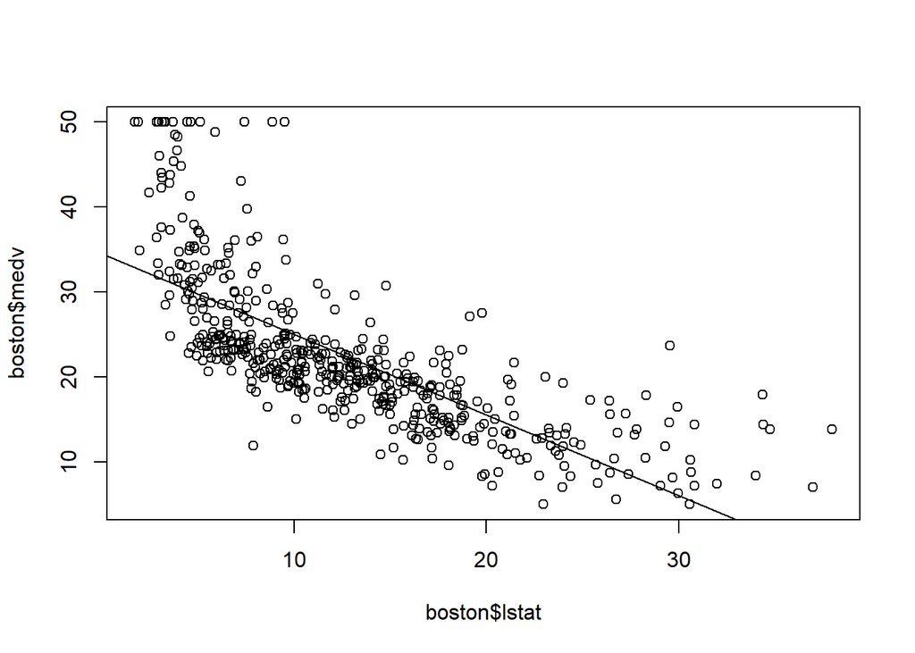

```r
plot(boston$lstat, boston$medv )
abline(lm_fit )
```

Let’s also plot this using the tidyverse. I’m not sure how to put the regression line on there.

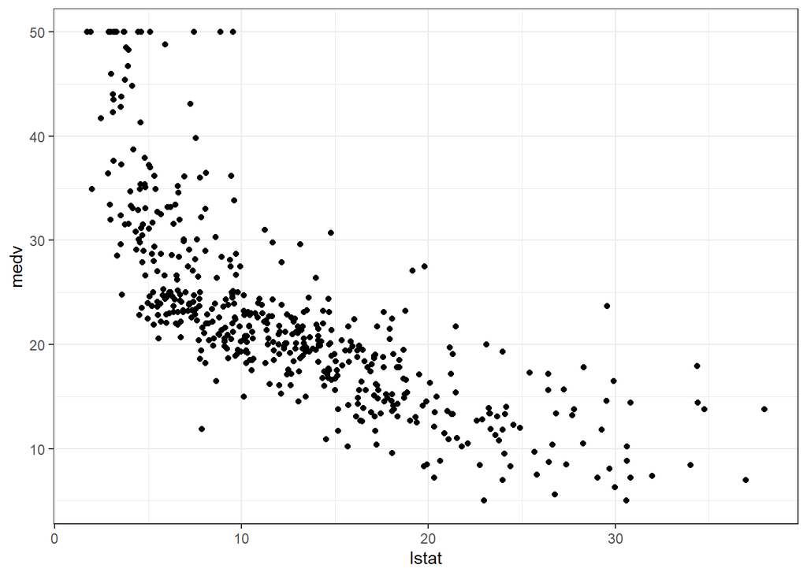

```r
boston %>%
  ggplot(aes(lstat, medv)) +
  geom_point() +
  theme_bw()
```

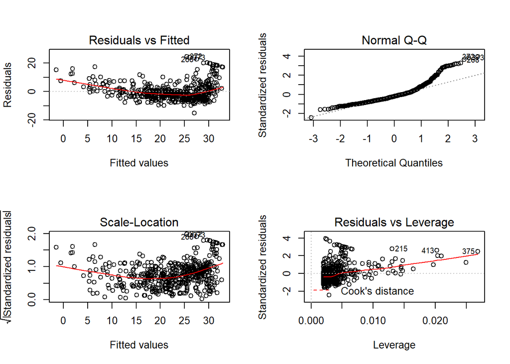

```r
par( mfrow=c(2,2))
plot(lm_fit)
```

Alternatively, we can compute the residuals from a linear regression fit using the residuals() function. The function rstudent() will return the residuals() studentized residuals, and we can use this function to plot the residuals rstudent() against the fitted values.

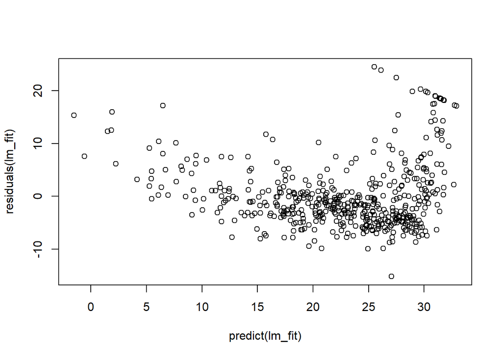

```r
plot(predict(lm_fit ), residuals(lm_fit ))
```

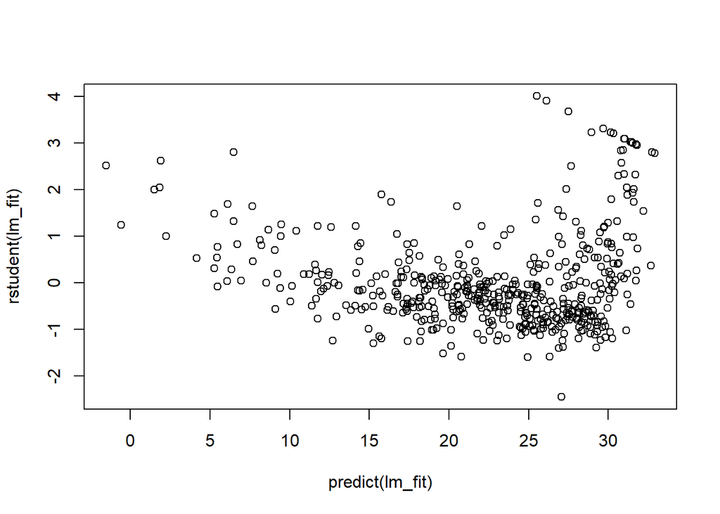

```r
plot(predict(lm_fit ), rstudent(lm_fit ))
```

On the basis of the residual plots, there is some evidence of non-linearity. Leverage statistics can be computed for any number of predictors using the hatvalues() function.

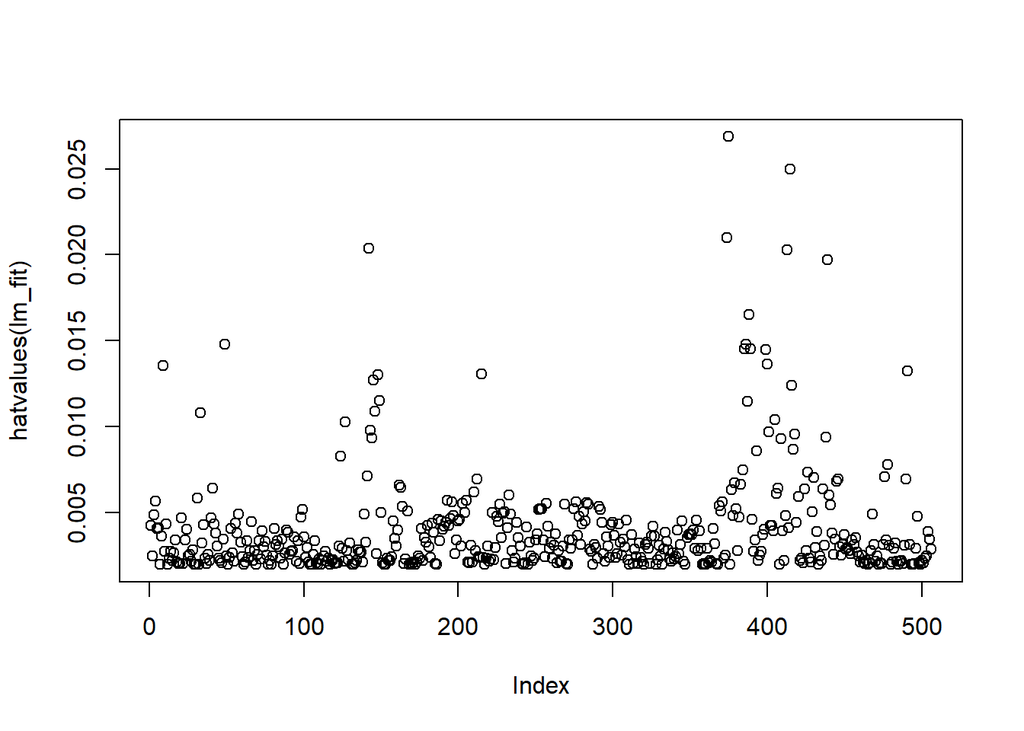

```r
plot(hatvalues(lm_fit))
```

```r
which.max(hatvalues(lm_fit))
```

```
## 375
## 375
```

The which.max() function identifies the index of the largest element of a which.max() vector. In this case, it tells us which observation has the largest leverage statistic (related to outliers in the predictor).